# Perceptions of Classical AI Across Demographics

Richard Liu, Eileena Mathews, Rachel Perry, Hayden Pozzi

2025-12-11

# Introduction

In recent years, artificial intelligence has become increasingly embedded in everyday life, shaping how people interact with services, information, and technology. This project examines how the public perceived these systems using data collected in late 2022—immediately before generative AI tools like ChatGPT entered mainstream awareness. Because this survey predates the recent surge in AI hype, it provides a valuable baseline for attitudes toward classical, non-generative AI systems that people were actually encountering at the time (e.g., facial recognition, automated decision tools, and robotic care assistants).

The dataset we use is the **Public Attitudes to AI** survey from the Ada Lovelace Institute, which includes more than 4,000 UK respondents and 715 structured variables. It contains detailed measures of demographics, AI awareness, perceived benefits, and concerns across multiple domains. Since classical and generative AI are often conflated today, the timing of this dataset allows us to isolate perceptions of classical AI before generative models began reshaping public understanding.

Early exploratory plots in our analysis suggested meaningful demographic patterns—particularly by age, gender, and education—and these differences appeared especially pronounced in accessibility-related technologies such as Robotic Care Assistants (RCAs). These initial observations motivated the central question guiding our work:

**How do demographic characteristics shape public attitudes toward classical AI systems?**

To answer this, we combine descriptive summaries with regression models to test which demographic factors meaningfully predict perceived benefits or concerns. This structure allows us to move from broad patterns to statistical evidence, highlighting how different groups evaluate emerging AI technologies in a pre-LLM context.

## The Dataset:Public Attitudes to AI

**Understanding the variables** The dataset includes demographic variables such as age, sex, and region, along with a large set of binary columns prefixed with “benb_” that represent whether respondents selected specific perceived benefits of AI. Here we highlight the key variables used throughout our analysis. This table summarizes the most important features in our preprocessed dataset and provides the foundation for the models and visualizations presented below.

Key variables in the preprocessed dataset

| variable | description | type |
| --- | --- | --- |
| age | Respondent age in years | Numeric |
| sex | Self-identified gender (Male/Female/Other) | Categorical |
| benb_* | Binary indicators for perceived AI benefits | Integer (0/1) |
| weight | Survey weight (if applicable) | Numeric |

## Tidying up

We preform additional tidyding such as recoding technology labels to match natural language, listing demographic variables of interest, identifying and preparing key column key and creating “ai_clean” data set, standardizing variable names, detecting age and gender columns, identifying all AI benefit-related columns (benb_), and inspecting variables and “N/A” values.

However, for the sake of keeping our document conscise and informative, we have decided to omit these steps from our report. To view our further tidying, visit the associated **.Rmd** file.

Likewise, we will artfully omit code from our analysis. To use an engineering analogy, this is to concentrate the reader on the “signal” rather than the “noise”.

## Exploring Missingness

Before getting deeper into the data, we wanted to check for missing variable types to understand parts of the questionnaire that were left unanswered by parts of the survey population. This would give insight into variables that are interesting, but that might have missing context because of their lack of completion by survey respondents. We will not be using these in our analysis.

Top 10 Variables with the Highest Missingness

| variable | missing | missing_pct |
| --- | --- | --- |
| AI Governance – Who should ensure AI is used safely? | 3984 | 99.33 |
| AI & Loans (Benefits) – How can AI loan risk prediction be beneficial? | 3975 | 99.10 |
| Robotic Vacuums (Benefits) – How are robotic vacuums beneficial? | 3972 | 99.03 |
| AI & Loans (Concerns) – What are your concerns about AI loan risk prediction? | 3970 | 98.98 |
| Autonomous Weapons (Benefits) – How could autonomous weapons be beneficial? | 3969 | 98.95 |
| Face Recognition in Policing (Benefits) – How could it benefit policing/surveillance? | 3967 | 98.90 |
| Face Recognition at Borders (Benefits) – How could it benefit border control? | 3965 | 98.85 |
| AI & Climate Research (Benefits) – How could AI simulations help climate research? | 3962 | 98.78 |
| AI & Cancer Prediction (Benefits) – How could AI cancer prediction be beneficial? | 3961 | 98.75 |
| Targeted Ads (Benefits) – How could targeted social media ads be beneficial? | 3961 | 98.75 |

```r
# Age summaries
if ("age" %in% names(ai_clean)) {
ai_clean %>%
summarise(
mean_age = mean(age, na.rm = TRUE),
median_age = median(age, na.rm = TRUE),
sd_age = sd(age, na.rm = TRUE),
min_age = min(age, na.rm = TRUE),
max_age = max(age, na.rm = TRUE)
)
  age_stats <- ai_clean %>%
    summarise(
      n = sum(!is.na(age)),
      mean_age = mean(age, na.rm = TRUE),
      median_age = median(age, na.rm = TRUE),
      sd_age = sd(age, na.rm = TRUE),
      min_age = min(age, na.rm = TRUE),
      max_age = max(age, na.rm = TRUE)
    )
  print(age_stats)
}
```

```
## # A tibble: 1 × 6
##       n mean_age median_age sd_age min_age max_age
##   <int>    <dbl>      <int>  <dbl>   <int>   <int>
## 1  4005     48.1         47   17.2      18      94
```

```r
# Sex / gender distribution
if ("sex" %in% names(ai_clean)) {
ai_clean %>%
count(sex, sort = TRUE) %>%
mutate(percent = scales::percent(n / sum(n)))
  print(ai_clean %>% count(sex, sort = TRUE) %>% mutate(p = n / sum(n)))
}
```

```
## # A tibble: 3 × 3
##   sex        n        p
##   <chr>  <int>    <dbl>
## 1 Female  2096 0.523
## 2 Male    1911 0.476
## 3 <NA>       4 0.000997
```

## Visualizations and findings

**Age Histogram**

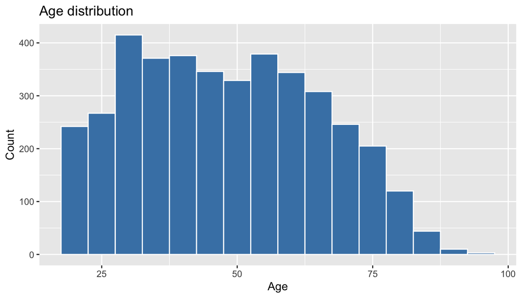

Because one of our core research questions examines how age shapes attitudes toward classical AI systems, confirming that we have a broad age range was essential. This distribution reassures us that the data include enough representation across younger, middle-aged, and older adults to meaningfully explore how attitudes may differ by age. The relatively smaller number of respondents over 70 is important to keep in mind, but the overall spread still provides a strong foundation for testing age-related patterns that appear in our later descriptive plots and regression models.

**Gender Distribution**

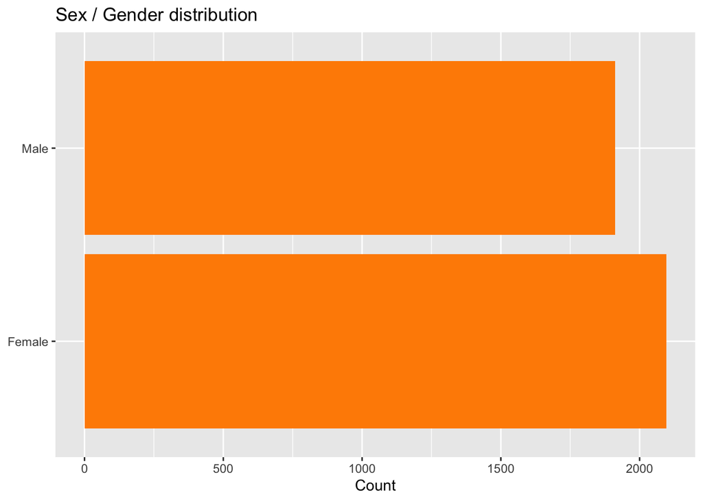

The chart shows that survey responses were evenly split between male and female participants, giving a balanced view of public attitudes toward AI. This balance helps ensure that later comparisons by gender aren’t biased by unequal sample sizes.

*Top 8 Perceived Benefits of AI*

**Derive Overall Benefit Tallies (Unweighted)**

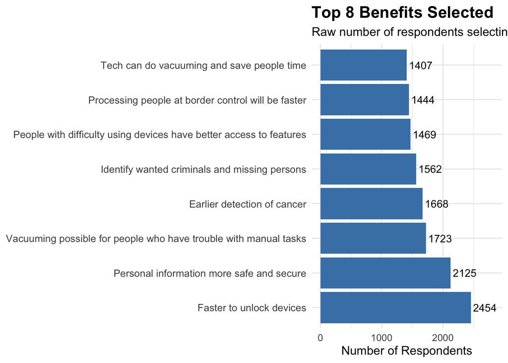

The raw response data suggests that there is no single dominant theme in how the public perceives the benefits of AI. Instead, respondents point to a wide range of everyday advantages—from faster device access to improved personal information security, enhanced accessibility for people with difficulty using devices, and support for public safety and border processes. These diverse selections show that people primarily associate AI with practical, non-generative tools that are already embedded in daily routines.

This broad spread of uses reinforced our interest in studying classical (non-generative) AI, since its applications appear more widespread and familiar to the public than any single high-profile technology. Because perceived benefits vary so widely, this figure also motivated us to examine whether demographic characteristics—such as age, gender, or education—shape which advantages individuals recognize.

## Looking deeper - AI Usage for Accessibility Purposes

Because the perceived benefits of AI span a variety of domains, we next focused our analysis on a specific application to better understand how attitudes differ across demographic groups. We selected Robo-vacuums and robotic care assistants (RCAs) as a case example: everyday forms of classical AI that can meaningfully improve accessibility, particularly for individuals with mobility limitations or other disabilities. Prior research has noted that assistive cleaning technologies can reduce physical strain and support independent living among vulnerable populations*([Cleaning Is Caring, n.d.)](https://www.cleaningiscaring.org/wpd/disability-friendly-cleaning/)*.

RCAs are especially interesting in the context of our project because, as highlighted in our presentation, awareness of these technologies is relatively similar across age groups, even though RCAs are often designed to support older adults or people who benefit from additional assistance in daily tasks. This combination—broad, cross-age familiarity paired with potentially age-specific usefulness—makes RCAs a compelling domain for testing whether demographic characteristics such as age, gender, and education shape how people perceive accessibility-related benefits of AI.

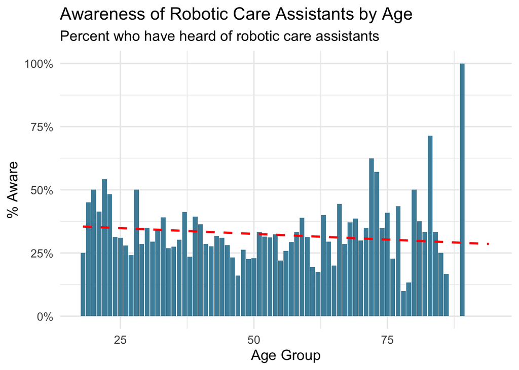

Although the bar heights suggest some fluctuation in awareness across ages, the overall pattern reveals that awareness of robotic care assistants is relatively low and does not meaningfully change with age. This means that despite RCAs being designed to support older adults and individuals who may benefit from additional assistance, familiarity with these technologies is not concentrated in any particular age group. Instead, most respondents—regardless of age—report limited awareness.

The subtle downward slope in the regression line likely reflects sampling variation, particularly because respondents over 75 make up only a small portion of the dataset, resulting in greater noise in the oldest age groups. Still, the broader takeaway remains clear: people’s attitudes toward RCAs are shaped in a context where many have heard little about them, making this domain especially useful for examining how demographic factors, rather than direct exposure, influence perceptions of AI designed for care and accessibility.

This pattern reinforced our choice to focus on RCAs as a case study. Their cross-age relevance, paired with low and relatively uniform awareness, makes them a compelling technology for investigating how age, gender, education, and other demographic predictors shape perceptions of assistive AI.

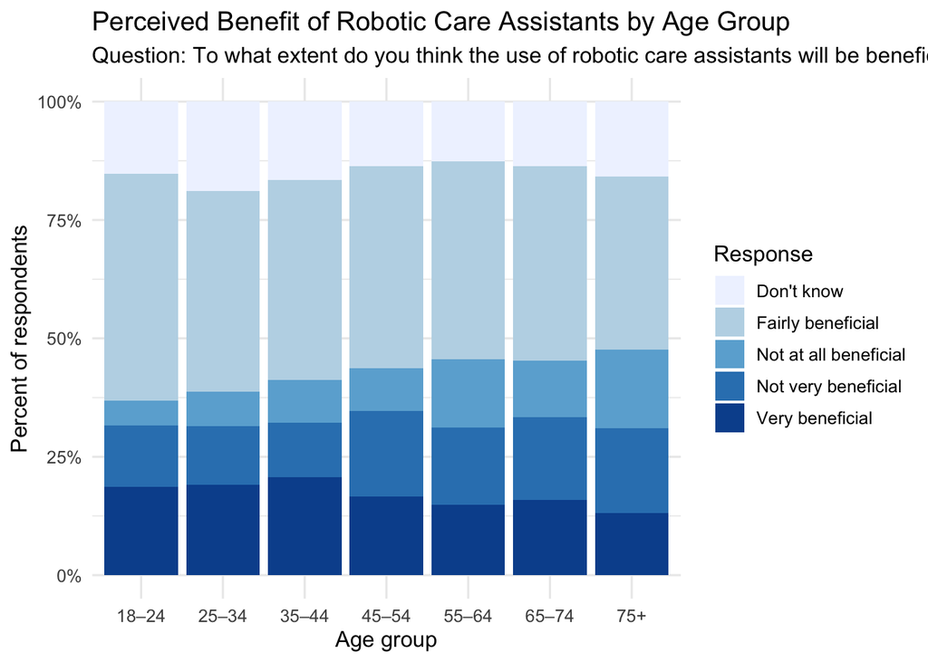

Across all age groups, most respondents believe that robotic care assistants would be at least “fairly beneficial,” indicating broad, baseline positivity toward this type of assistive technology. However, the distribution of responses also reveals subtle demographic patterns consistent with what we highlighted in our presentation: older adults appear somewhat less likely to select the highest benefit categories, while younger and middle-aged respondents show slightly stronger enthusiasm.

At the same time, “don’t know” responses remain relatively common across all age bands, reinforcing our earlier point that many people are forming opinions about RCAs without extensive familiarity.

Taken together, this figure suggests that while attitudes toward RCAs are generally positive, age may still play a modest role in shaping perceived benefit. This descriptive pattern motivated us to test these differences more formally through regression modeling in the next section.

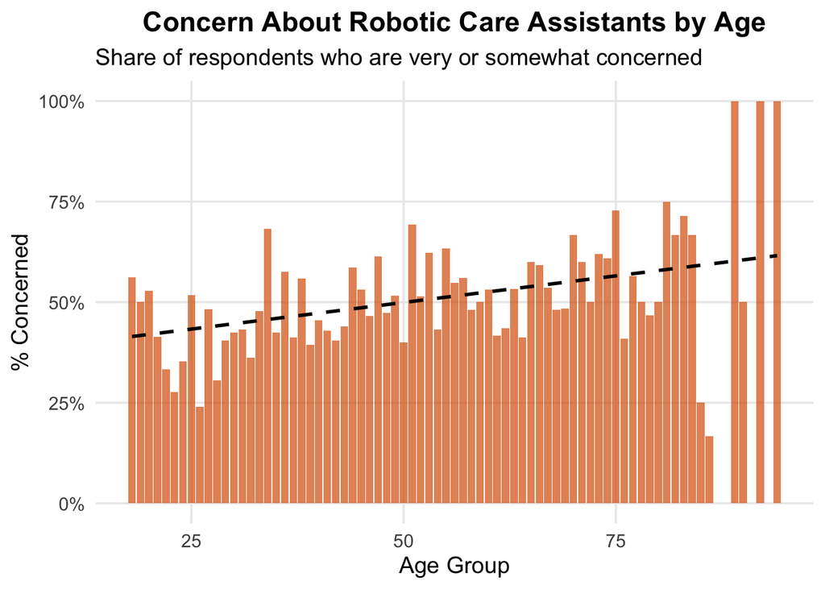

Concern about robotic care assistants shows a clear upward trend with age, suggesting that older adults are somewhat more wary of this technology. This aligns with patterns highlighted in our presentation, where age emerged as a meaningful predictor of caution toward assistive AI. However, the bar heights also reveal that elevated concern is present across all age groups, not just older respondents. Even younger adults show substantial levels of concern, indicating that unease around RCAs is a broadly shared sentiment rather than an older-adult phenomenon.

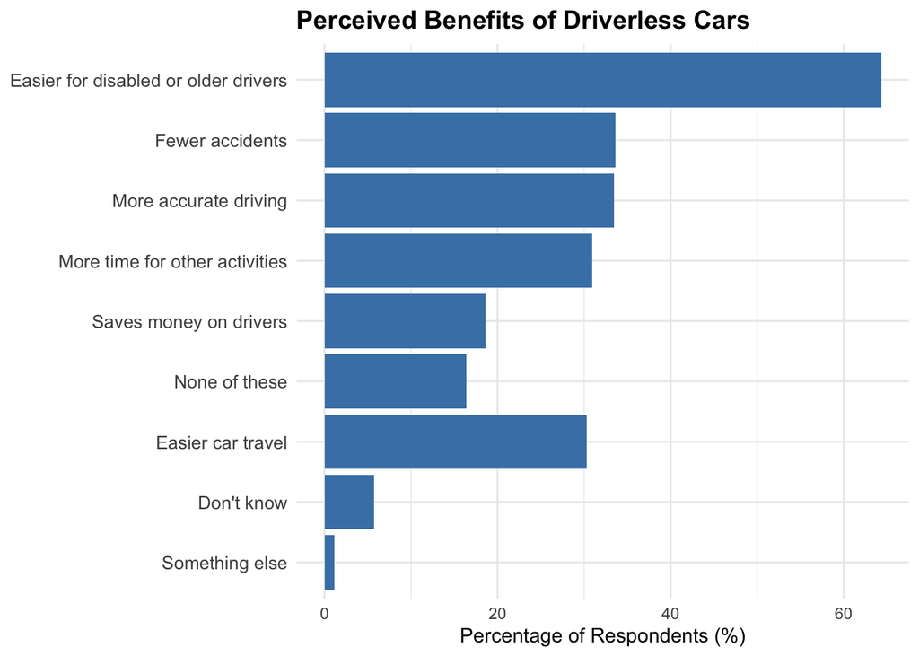

Respondents highlight a range of potential advantages of driverless cars, but the most commonly selected benefit is their ability to make driving easier for disabled or older adults. This aligns with the broader pattern we observed in our analysis: many perceived benefits of classical AI technologies relate to accessibility, reduced physical strain, and increased independence for vulnerable populations. Safety-related benefits, such as fewer accidents and more accurate driving, also rank highly, suggesting that respondents associate driverless cars with both personal convenience and public safety.

## Exploring Benefit Score vs. Age: Bridge to Modeling

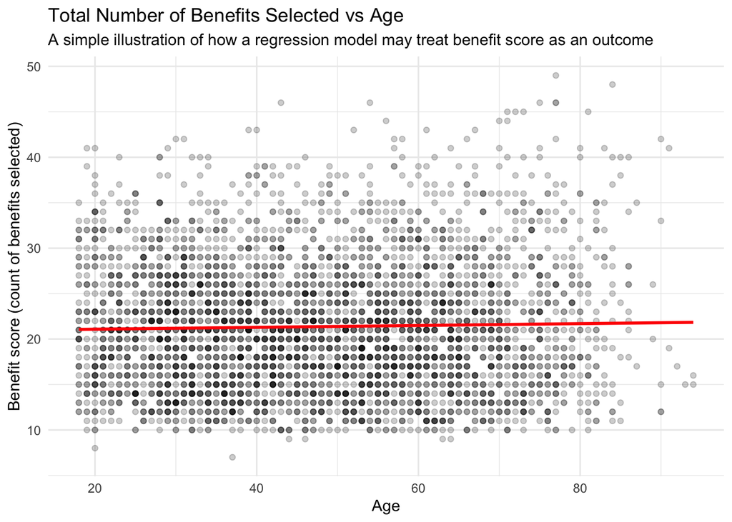

The scatterplot shows that although people across all ages select a wide range of AI benefits, there is no strong linear relationship between age and the total number of benefits selected. The regression line is almost flat, suggesting that older adults are not necessarily more or less likely than younger adults to see AI as beneficial overall.

However, the large spread in benefit scores at every age indicates that age alone cannot explain variation in attitudes. This reinforces why a regression model is needed: to test how age interacts with other factors such as gender, education, socio-economic status, and awareness—to more accurately predict who perceives AI as beneficial.

## Model 1: Benefit Score ~ Age

```
##
## Call:
## lm(formula = model_benefit_score ~ age, data = model_df)
##
## Residuals:
##      Min       1Q   Median       3Q      Max
## -14.2616  -5.4329  -0.5488   4.5772  27.3354
##
## Coefficients:
##             Estimate Std. Error t value Pr(>|t|)
## (Intercept) 20.88879    0.32940  63.415   <2e-16 ***
## age          0.01008    0.00645   1.562    0.118
## ---
## Signif. codes:  0 '***' 0.001 '**' 0.01 '*' 0.05 '.' 0.1 ' ' 1
##
## Residual standard error: 7.02 on 4000 degrees of freedom
## Multiple R-squared:  0.0006098,  Adjusted R-squared:  0.0003599
## F-statistic: 2.441 on 1 and 4000 DF,  p-value: 0.1183
```

Age is not a significant predictor of the total number of AI benefits a respondent selects. The estimated slope is very close to zero, and the associated p-value is far too large to suggest any meaningful relationship between age and benefit scores. In fact, the model explains almost none of the variation in perceived benefits. This aligns with our earlier scatterplot: people across all age groups report similar levels of perceived benefit, indicating that age alone does not drive how many advantages individuals attribute to AI.

## Model 2: Logistic Regression (Who thinks RCAs are beneficial?)

```
##
## Call:
## glm(formula = rca_beneficial ~ age + sex + rs_education_level +
##     dr_socio_eco, family = binomial(), data = model_df)
##
## Coefficients:
##                                      Estimate Std. Error z value Pr(>|z|)
## (Intercept)                          1.756790   0.220834   7.955 1.79e-15 ***
## age                                 -0.014874   0.003932  -3.783 0.000155 ***
## sexMale                              0.603629   0.123128   4.902 9.47e-07 ***
## rs_education_levelNon-degree        -0.397236   0.136905  -2.902 0.003713 **
## rs_education_levelNo qualifications -0.831529   0.275778  -3.015 0.002568 **
## dr_socio_eco2                       -0.390210   0.170458  -2.289 0.022069 *
## dr_socio_eco3                       -0.370080   0.226984  -1.630 0.103013
## dr_socio_eco4                       -0.118313   0.316021  -0.374 0.708118
## dr_socio_eco5                       -0.428779   0.174847  -2.452 0.014194 *
## dr_socio_eco6                        0.220682   0.365030   0.605 0.545472
## dr_socio_eco7                        0.109431   0.313256   0.349 0.726838
## ---
## Signif. codes:  0 '***' 0.001 '**' 0.01 '*' 0.05 '.' 0.1 ' ' 1
##
## (Dispersion parameter for binomial family taken to be 1)
##
##     Null deviance: 1810.1  on 1494  degrees of freedom
## Residual deviance: 1718.1  on 1484  degrees of freedom
##   (2507 observations deleted due to missingness)
## AIC: 1740.1
##
## Number of Fisher Scoring iterations: 4
```

In this model, several demographic variables significantly predict whether respondents view robotic care assistants as beneficial.

First, **age has a small but statistically significant negative association** with perceived benefit (p < 0.001). Although the effect size is modest, the negative coefficient indicates that **older adults are slightly less likely** to view RCAs positively—an insight consistent with our earlier descriptive findings.

Education shows a clear gradient. Compared to respondents with degree-level qualifications, those with **non-degree qualifications or no formal qualifications** are significantly less likely to view RCAs as beneficial (both p < 0.01). This suggests that familiarity with technology or higher educational attainment may shape comfort with or perceived usefulness of AI in care settings.

Socioeconomic classification exhibits smaller and more mixed effects—some SEC groups show reduced odds of perceiving RCAs as beneficial, though these effects are less consistent across categories.

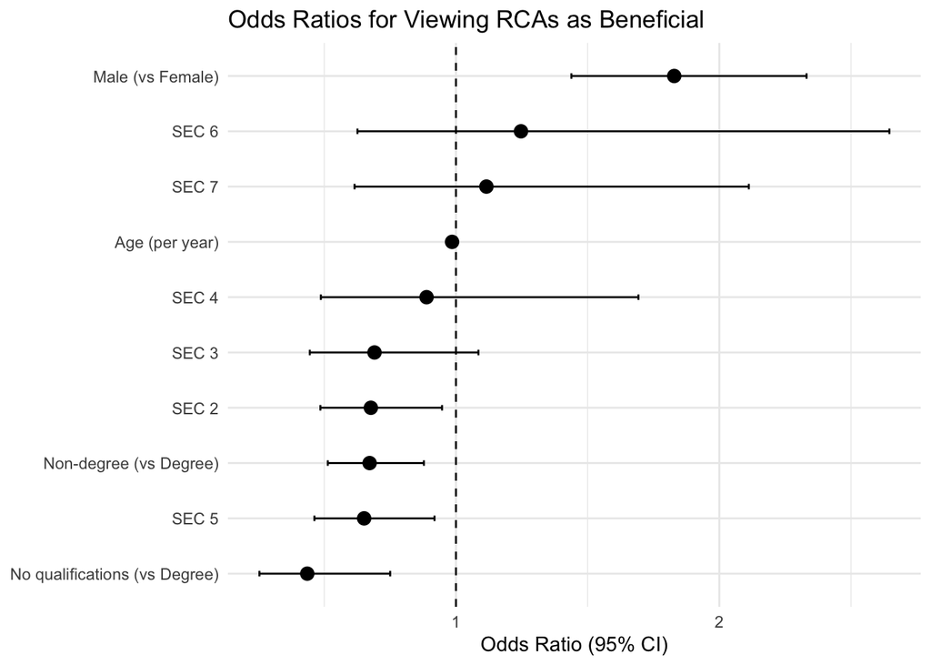

The odds-ratio plot reinforces the regression results: men have substantially higher odds of viewing RCAs as beneficial, while respondents with lower educational attainment have meaningfully lower odds compared to those with degrees. Age shows a small but significant negative association, reflected by an odds ratio slightly below 1. Socioeconomic categories vary, but most hover near 1 with wide confidence intervals, indicating weaker or inconsistent effects. Overall, these patterns mirror the conclusions from Model 2 and visually highlight which demographic characteristics have the strongest influence on perceived benefit.

## Model 3: Logistic Regression (Who is concerned about RCAs?)

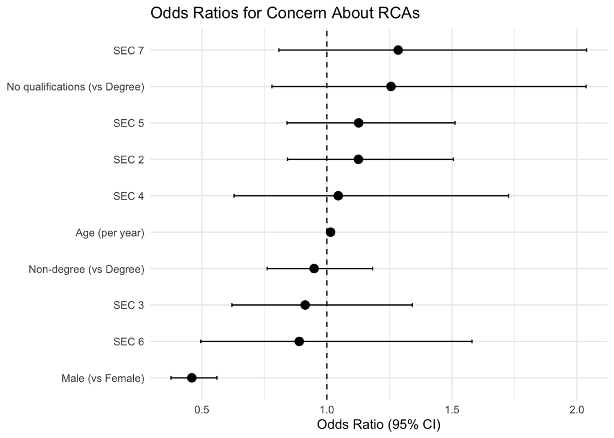

Gender shows the opposite pattern of the benefit model: the large negative coefficient for sexMale (p < 0.001) means that men are substantially less likely than women to be concerned about RCAs. In other words, **women are more likely to express worry about this technology**, even after controlling for age, education, and socioeconomic status.

By contrast to the benefist model, education level is not a strong predictor of concern once other variables are included. Neither non-degree qualifications nor having no formal qualifications differ significantly from degree-holders in their odds of being concerned. The socioeconomic status indicators (SEC categories) also hover near zero and are not statistically significant, suggesting that class-based differences in concern are relatively weak in this model.

Taken together, Model 3 shows that age and gender, rather than education or socioeconomic status, are the main demographic drivers of concern about RCAs: **older adults and women are more likely to be uneasy about this form of assistive AI**, even though awareness is relatively similar across age groups.

## Conclusion

Our analysis of the Public Attitudes to AI dataset shows that perceptions of classical AI technologies—including robotic care assistants—vary across demographic groups in meaningful but nuanced ways. While descriptive patterns suggested broad familiarity gaps and mixed reactions across age groups, the regression models help clarify which characteristics actually shape attitudes once multiple factors are considered simultaneously.

## Future Direction

The models in this notebook focus on broad demographic predictors of how people view robotic care assistants. A natural next step would be to incorporate more direct measures of accessibility and disability—such as disability status, mobility limitations, and caring responsibilities—to better understand whether those who stand to benefit most from assistive technologies are more likely to view them as useful or concerning. Including measures of technology experience, confidence, and familiarity would also help clarify whether attitudes reflect practical exposure or broader feelings of trust in AI.

Methodologically, future work could explore interaction terms (for example, age × disability or gender × technology comfort) to test whether demographic groups respond differently depending on their everyday relationship with technology. Applying survey weights and more flexible modeling strategies—such as logistic regression with interactions, regularized models, or multilevel approaches—would allow these findings to generalize more reliably to the UK population.

There is also an important practical dimension: **as generative AI systems dominate public conversations about artificial intelligence, companies developing classical, non-generative AI systems have strong incentives to understand how their technologies are perceived**. Many longstanding applications of AI in healthcare, transportation, and accessibility have been overshadowed by narratives about ChatGPT and other generative tools. Mapping public attitudes toward non-generative AI can help these companies communicate their value, address sources of concern, and ensure that the benefits of assistive technologies are visible to the groups they are designed to support.